# GAN_Advanced_R

**Following markdown is just a documentation** - code is splitted into chunks to enhance its clarity.  
Codes that can be runned are placed in different files.

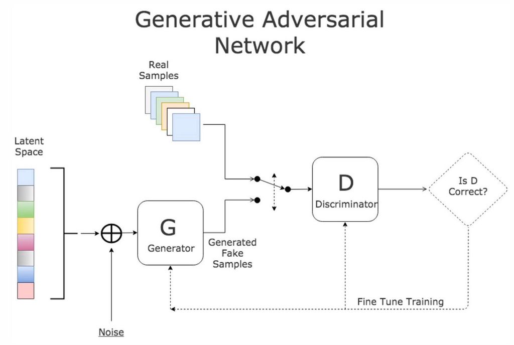

### Function flowchart

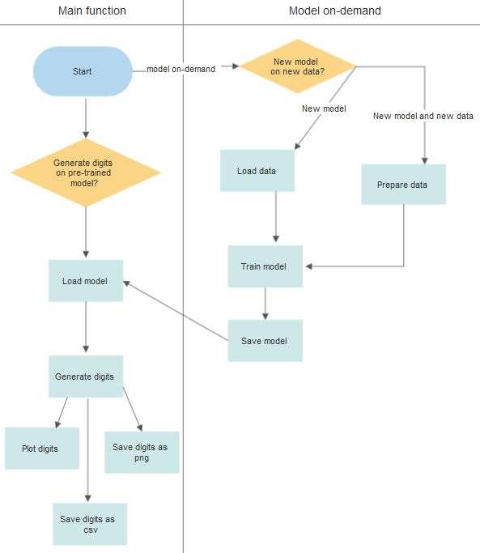

### Dataset containing ~ 50000 images:

Source: https://github.com/kensanata/numbers

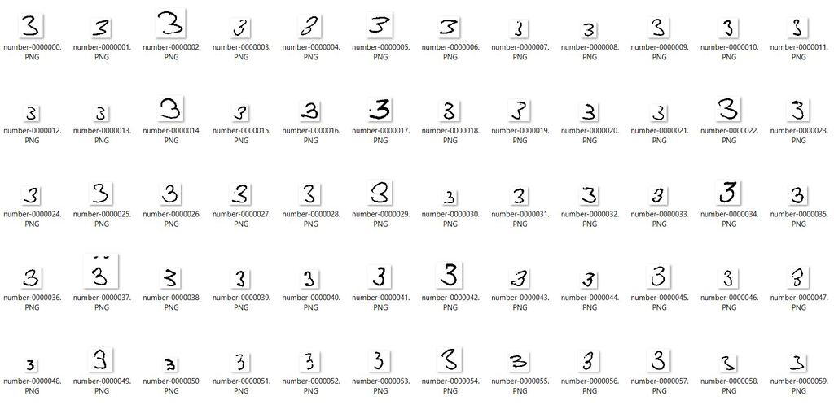

### Results:

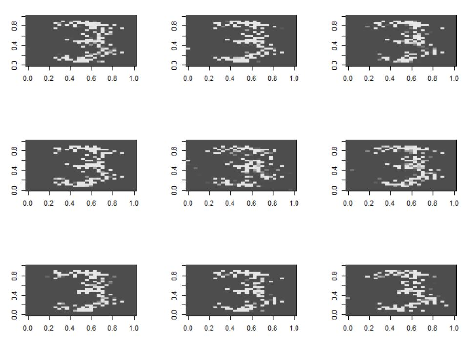

Remember to open the project by clicking on the **gan_r.Rproj** or set working directory to “./gan_digits”.

## Generate digits (**generate_digits.R**)

Load required packages:

```r
 if(!require(imager)){
  install.packages('imager')
  library(imager)
} else {
  library(imager)
}

if(!require(testit)){
  install.packages('testit')
  library(testit)
} else {
  library(testit)
}
```

Function **generate_digits** has two possible routes:

- You can either train on demand model that will generate digits or
- You can load already trained model and then generate digits.

```r
generate_digits <- function(# simple generating digits with already computed model
                            digit_to_generate = NULL,
                            plot_data = FALSE,
                            save_data = FALSE,
                            csv_path = "generated_digits.csv",
                            save_data_as_png = FALSE,
                            num_of_digits_to_generate = 9,

                            # route with network on demand
                            network_on_demand = FALSE,
                              prepare_data = FALSE,
                                data_folder_path = "3/",
                                dataset_file_path = "data/threes.csv",
                                  image_quantity = 1000,
                                  hidden_layers = 10,
                                  learning_rate = 0.1,
                                  batchsize = 300,
                                  num_of_epochs = 20,
                                  image_resolution = 28,
                            display_generation_image = TRUE,
                            save_model = FALSE,
                            model_save_path = "models/test_model.RData",

                            # path for the model to load (if model_save_path is specified then it has to be equal)
                            model_file_name = "neural_network/models/model_3.RData") {
```

First it checks if numeric arguments have good format

```r
  # checking format of numeric arguments
  if (!is.numeric(c(digit_to_generate,num_of_digits_to_generate,
                  image_quantity,hidden_layers,learning_rate,
                  batchsize,num_of_epochs,image_resolution))) {
    stop("Model hyperparameters are not all numeric")
  }
```

Routes are being chosen by setting parameters to desired values.  
One can also choose if one wants to plot generated digits, save them as matrix in csv or as pngs.

If one wants to use the full capability of the function, e.g. train new model and prepare data for it, one has to set **network_on_demand** to **TRUE** and **prepare_data** to **TRUE** as well as all the paths to data and models (or use the default ones). One have possibility to choose most of the model hyperparameters. In this case the snippet below will be used.

It loads function *main_network* from *main.R* (that will be covered later), sets up the network, creates model based on one’s hyperparameters and dataset and saves it to RData file.

```r
  if (isTRUE(network_on_demand)) {
    # route with network on demand

    source("neural_network/main.R")

    main_network(dataset_file_path = dataset_file_path,
                 prepare_data = prepare_data,
                 data_folder_path = data_folder_path,
                 image_quantity = image_quantity,
                 hidden_layers = hidden_layers,
                 learning_rate = learning_rate,
                 batchsize = batchsize,
                 num_of_epochs = num_of_epochs,
                 image_resolution = image_resolution,
                 matrix_columns_from = 2,
                 matrix_columns_until = 785,
                 plot_digits = FALSE,
                 display_generation_image = display_generation_image,
                 save_model = save_model,
                 model_file_name = model_save_path)

    setwd("..")
  }
```

Following snippet covers route in which one specifies number of digits to create (integer). No matter if one choosed to generate new model or choosed exisitng model it will load the one specified as **model_file_name**. By loading *gan.R* script all utility functions for neural network are being load and then used to generate new digits.

```r
  if (is.numeric(digit_to_generate)) {
    # load utility functions
    source("neural_network/gan.R")
  }


  if (!is.numeric(digit_to_generate)) {

    stop("Specify digit_to_generate as an integer")

  } else if (digit_to_generate == 3) {

      # load desired model data (plus generator and discriminator)
      load(model_file_name)

      # creating global variables to store both models
      g_nn <<- g_nn
      d_nn <<- d_nn

      # generate new data - specify model and number of new data elements
      generation<<-generator(gan_model,num_of_digits_to_generate)

  } else if (digit_to_generate != 3) {
    # hardcoded for now (replace with desired digit)
    stop("There is no model that can generate that digit_to_generate")

  }
```

In the final step it either plots the data, saves it as csv, save it as pngs or it does it all :)

```r
  if (!is.logical(plot_data) | !is.logical(save_data)) {

    stop("'show_data' and 'save_data' have to be logical")

    }


  plot_digit <- function(q) {
    image(rotate(matrix(unlist(generation[q,]),nrow = 28, byrow = TRUE)), col=grey.colors(255))
  }

  if (isTRUE(plot_data) & is.numeric(digit_to_generate) & digit_to_generate == 3) {
    # draw new data (remember to enlarge plot window!!!)
    par(mfrow=c(3,3))
    lapply(1:min(num_of_digits_to_generate, 9), plot_digit)
  }


  if (isTRUE(save_data) & is.numeric(digit_to_generate) & digit_to_generate == 3){
    # save data to a file
    write.csv(generation, csv_path)
  }

  save_digit_as_png <- function(q) {
    im <- as.cimg(rotate(matrix(unlist(generation[q,]),nrow = 28, byrow = TRUE)))
    save.image(im, paste("created_digits/",q, ".png"))
  }

  if (isTRUE(save_data_as_png) & is.numeric(digit_to_generate) & digit_to_generate == 3){
    lapply(1:min(num_of_digits_to_generate, 9), save_digit_as_png)
  }

}
```

### Calling function generate_digits

```r
# the easiest path
generate_digits(digit_to_generate = 3,
                plot_data = TRUE,
                save_data = FALSE,
                save_data_as_png = TRUE,
                num_of_digits_to_generate = 11,
                model_file_name = "neural_network/models/model_3_1000_50.RData")


# full potential
generate_digits(digit_to_generate = 3,
                plot_data = TRUE,
                save_data = FALSE,
                save_data_as_png = TRUE,
                num_of_digits_to_generate = 9,
                # route with network on demand
                network_on_demand = TRUE,
                dataset_file_path = "data/test_test.csv",
                data_folder_path = "3/",
                image_quantity = 2001,
                hidden_layers = 20,
                learning_rate = 0.1,
                batchsize = 600,
                num_of_epochs = 6,
                image_resolution = 28,
                prepare_data = TRUE,
                display_generation_image = TRUE,
                save_model = TRUE,
                model_save_path = "models/model_3_test.RData",
                model_file_name = "neural_network/models/model_3_test.RData")
```

## GAN - neural networks (**main.R**)

Function that uses utilities from *gan.R* and *data_prepare.R* to create two neural network models and combine them to create generative adversarial network.

Functions in *gan.R* are copied from https://github.com/LeeGyeongTak/generative-adversarial-networks-. We transformed them a little bit for our purpose and treated them as a library/package.

There is an option to prepare dataset from your own images, using *data_prepare.R* (it will be covered later).

```r
main_network <- function(dataset_file_path = "data/trojki_full.csv",
                         prepare_data = FALSE,
                         data_folder_path = "3/",
                         image_quantity = 100,
                         hidden_layers = 10,
                         learning_rate = 0.1,
                         batchsize = 300,
                         num_of_epochs = 20,
                         image_resolution = 28,
                         matrix_columns_from = 2,
                         matrix_columns_until = 785,
                         plot_digits = FALSE,
                         display_generation_image = FALSE,
                         save_model = FALSE,
                         model_file_name = "models/test_model.RData") {

  setwd("./neural_network")

  source("gan.R")
  source("data_prepare.R")

  if (isTRUE(prepare_data)){
    cat("Preparing data this may take aprox:", round(image_quantity*0.03), "sec")
    data_prepare(folder_path = data_folder_path,
                 destination_file = dataset_file_path,
                 image_quantity = image_quantity,
                 resizing_to = image_resolution)
  }

  train<-read.csv(dataset_file_path)

  # load the data / normalize it / tranforms it into matrix
  x <- read.csv(dataset_file_path) %>%
    .[,matrix_columns_from:matrix_columns_until] %>%
    '/'(255) %>%
    as.matrix(.)

  ### initialize models as global variables
  # generator
  g_nn<<-nn_model(input_dim=image_resolution*image_resolution,
                  hidden=hidden_layers,
                  output_dim=image_resolution*image_resolution,
                  learningrate=learning_rate,
                  activationfun="relu",
                  output="sigm" )
  # discriminator
  d_nn<<-nn_model(input_dim=image_resolution*image_resolution,
                  hidden=hidden_layers,
                  output_dim=1,
                  learningrate=learning_rate,
                  activationfun="relu",
                  output="sigm" )

  numdata<-dim(train)[1]
  num_f<-numdata* g_nn$input_dim
  num_d<-numdata* d_nn$input_dim

  ### traning GAN using generator and discriminator
  # if you wish you can specify display_generation_image = T to display plots of generated digits as the network is being trained
  ganmodel<-gan(x,g_nn,d_nn,
                batchsize = batchsize,
                epoch = num_of_epochs,
                disc_step=1,
                display_generation_distribution = F,
                display_generation_image = display_generation_image)

  ### After training model will be saved "gan_model".
  gan_model$loss

  generation<-generator(gan_model,9)

  if (isTRUE(plot_digits)) {
    # plotting generated digits (9 of them)

    rotate <- function(x) t(apply(x, 2, rev))

    par(mfrow=c(3,3))
    lapply(1:9,
           function(q) image(
             rotate(matrix(unlist(generation[q,]),nrow = image_resolution, byrow = TRUE)),
             col=grey.colors(255)
           )
  )
  }

  if (isTRUE(save_model)) {
    # saving model, generator and discriminator into RData file
    save(gan_model, g_nn, d_nn, file=model_file_name)
  }


}
```

There is an option that you can run the model without *generate_digits.R*, simply upload the function *main_network* and run the code below. It works analogous to the *generate_digits.R*.

```r
main_network(dataset_file_path = "data/trojki_full.csv",
             prepare_data = FALSE,
             data_folder_path = "3/",
             image_quantity = 2000,
             hidden_layers = 30,
             learning_rate = 0.1,
             batchsize = 300,
             num_of_epochs = 30,
             image_resolution = 28,
             matrix_columns_from = 2,
             matrix_columns_until = 785,
             plot_digits = TRUE,
             save_model = TRUE,
             model_file_name = "models/test_model.RData")
```

## Data prepare (**data_prepare.R**)

THe last function that is being used is *data_prepare*. It loads **image_quantity** of png images in **folder_path**. Then resize those images to **resizing_to** x **resizing_to** resolution and save them to **destination_file**. This function can be used on new dataset and separatly from function presented above, but only if inputed images are two dimensional (meaning that they have to be greyscaled).

```r
data_prepare <- function(folder_path="3/",
                         destination_file = "threes_test.csv",
                         image_quantity = 10,
                         resizing_to = 28) {

  # loading all file names into one list
  files <- list.files(path=folder_path, pattern="*.PNG", full.names=TRUE, recursive=FALSE)

  image_quantity <- min(length(files), image_quantity)

  df <- data.frame()
  image_number = 0

  # resizing images and transforming them into 1-dim vectors and appending them to one dataframe
  for (file in files) {
    if (image_number <= image_quantity) {
      dfTemp <-  file %>%
        load.image() %>%
        resize(., size_x=resizing_to, size_y=resizing_to) %>%
        as.matrix(.) %>%
        as.vector(.) %>%
        matrix(., nrow = 1) %>%
        data.frame(.)

      df <- rbind(df, dfTemp)
    }
    image_number = image_number + 1
  }

  # encoding values to either 0 or 255 for better distinction
  color_update <- function(x){
    if (x == 1) {
      x <- 0
    } else if (x == 0) {
      x <- 255
    }
  }

  df <- data.frame(apply(df, c(1,2), color_update))

  # saving file
  write.csv(df, file = destination_file)
}
```